# Using frequency analysis to explore the content of the addresses given by the United States.

Aboli Khairnar

Sept, 2020

```r
setwd("/My_Personal_PC/FALL_2020_COURSE_MATERIAL/NLP/Lecture 3/")
```

Extracting addresses given by the United States

```r
data <- read.csv('UN_speeches.csv')
data <- data[data$country == 'USA',]
```

Preprocessing the data:

```r
text <- pre_process_corpus(data, "text", replace_numbers = T,
                           root_gen = 'lemmatize', extra_stopwords = c("must", "can", "now",
                                                                       "will","people"), output_corpus = T)
substr(text[[1]]$content, 1, 100)
```

```
## [1] "one privilege extend warm congratulation unite state delegation election presidency twentyfifth sess"
```

```r
# build tokenizer
tokenizer <- function(x) {unlist(lapply(ngrams(words(x), 1), paste, collapse = " "), use.names = FALSE)}

# set lower bound
lbound <- round(0.015* length(text))

# create DTM
dtm1 <- as.matrix(DocumentTermMatrix(text,
                          control = list(tokenize = tokenizer,
                                        bounds = list(global = c(lbound, Inf)))))

# create bigram DTM
tokenizer <- function(x) {unlist(lapply(ngrams(words(x), 2), paste, collapse = " "), use.names = FALSE)}

dtm2 <- as.matrix(DocumentTermMatrix(text,
                          control = list(tokenize = tokenizer,
                                        bounds = list(global = c(lbound, Inf)))))

# create trigram DTM
tokenizer <- function(x) {unlist(lapply(ngrams(words(x), 3), paste, collapse = " "), use.names = FALSE)}

dtm3 <- as.matrix(DocumentTermMatrix(text,
                          control = list(tokenize = tokenizer,
                                        bounds = list(global = c(lbound, Inf)))))
dtm <- cbind(dtm1, dtm2)
dtm <- cbind(dtm, dtm3)
dim(dtm)
```

```
## [1]     47 165174
```

```r
#Term frequency
freq_table <- data.frame(term = colnames(dtm), n = colSums(dtm),
                         freq = colSums(dtm)/sum(dtm))

freq_table <- freq_table[order(freq_table$n, decreasing = T),]
head(freq_table)
```

```
##                      term    n        freq
## nation             nation 1694 0.006028813
## unite               unite 1541 0.005484298
## world               world 1067 0.003797369
## state               state  960 0.003416565
## unite nation unite nation  790 0.002811548
## unite state   unite state  696 0.002477009
```

### 1. Which terms appear the most frequently in the corpus?

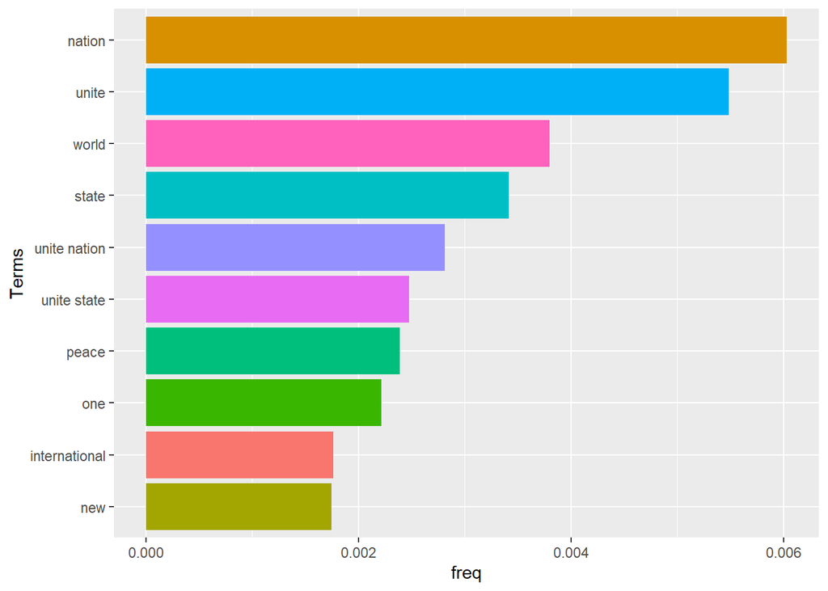

```r
df <- freq_table[1:10,]

ggplot(df,aes(x = reorder(term, freq), y = freq, fill = term)) +
  geom_bar(stat = "identity", show.legend = F) + coord_flip() + xlab("Terms")
```

Top 10 most frequent terms: nation, unite, world, state, unite nation, unite state, peace, one, international & new

### 2. Which 10 countries’ names have been mentioned most often and what is their frequency?

```r
#install.packages("countrycode")
library(maps)
x <- map("world", plot=FALSE)
country <- (x$names)

country[1:10]
```

```
##  [1] "Aruba"                             "Afghanistan"
##  [3] "Angola"                            "Angola:Cabinda"
##  [5] "Anguilla"                          "Albania"
##  [7] "Finland:Aland Islands:Foglo"       "Finland:Aland Islands:Eckero"
##  [9] "Finland:Aland Islands:Fasta Aland" "Andorra"
```

```r
countries <- tolower(unique(country))
df <- freq_table[freq_table$term %in% countries, ][1:10,]

head(df,10)
```

```
##                    term   n         freq
## iraq               iraq 140 4.982490e-04
## israel           israel  85 3.025083e-04
## afghanistan afghanistan  72 2.562423e-04
## iran               iran  71 2.526834e-04
## china             china  52 1.850639e-04
## russia           russia  51 1.815050e-04
## syria             syria  37 1.316801e-04
## lebanon         lebanon  34 1.210033e-04
## cyprus           cyprus  27 9.609088e-05
## namibia         namibia  25 8.897304e-05
```

### 3. Make a visual of these 10 countries and their frequencies

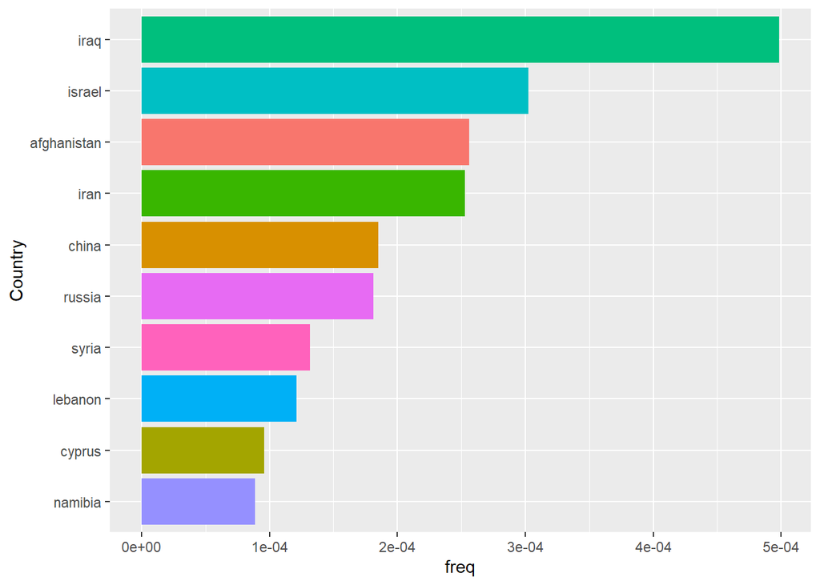

```r
ggplot(df,aes(x = reorder(term, df$freq), y = freq, fill = term)) +
  geom_bar(stat = "identity", show.legend = F) + coord_flip() + xlab("Country")
```

### 4. Of the 5 countries with the highest term count, compare the counts to the mentions of the United States. Show how these terms counts have changed over time.

Note: Mention of “united states” have been lemmatized to “unite state”

```r
countries <- df$term[1:5]
```

```r
terms <- c(countries, "unite state")
term_count <- dtm[, which(colnames(dtm) %in% sort(terms))]

colnames(term_count) <- terms
term_count <- data.frame(term_count)

# need a continous variable for time series
term_count$year <- 1970:2016
```

[figure not shown]

```r
df <- melt(term_count, id.vars = c("year"), variable.name = "term", value.name = "count")
ggplot(df, aes(x = year, y = count, color = term)) + geom_line(linetype = 2) + geom_point()
```